# Quality of Exercise Prediction

B Porter

May 13, 2016

## Loading Data and Exploratory Analysis

For this report we start by downloading the data set. The data for this project are available here: Training: https://d396qusza40orc.cloudfront.net/predmachlearn/pml-training.csv Validation Dataset: https://d396qusza40orc.cloudfront.net/predmachlearn/pml-testing.csv The data for this project come from this source: http://groupware.les.inf.puc-rio.br/har. The dataset is the Human Activity Recognition data set. It was collected by 6 participants wearing sensors on the arm, forearm, belt and a dumbbell. We are going to use this dataset to train a model to predict how well someone is doing a particular exercise based on the motions they are going through. We start by loading some required libraries.

```r
library(caret)
require(randomForest)
require(gbm)
require(plyr)
```

In order to load the data set we use read.csv and set the na.strings parameter so that the empty and ‘#DIV/0!’ entries will be set as NA values.

```r
train <- read.csv("https://d396qusza40orc.cloudfront.net/predmachlearn/pml-training.csv",na.strings=c("NA","#DIV/0!",""), header = T)
valid <- read.csv("https://d396qusza40orc.cloudfront.net/predmachlearn/pml-testing.csv",na.strings=c("NA","#DIV/0!",""), header = T)
dim(train)
```

```
## [1] 19622   160
```

```r
dim(valid)
```

```
## [1]  20 160
```

I used the str() and summary() functions to do some exploratory data analysis. I performed the exploratory data analysis on the training set so that I do not incorporate any of the validation set into the design. I am not going to print all this data into this portion because there are quite a few variables and can be difficult to read.

```r
str(train)
summary(train)
```

The next step that we need to perform is some cleaning of the data. In order to predict we are supposed to use data from the accelerometers on the belt, forearm, arm and dumbell. To start we remove the first seven columns as they are meta-data about the exercise such as the timestamp and user who performed the activity. We do not want this data to be included. We want to use accelerometer data only. It is important that we perform the same data transformations on both the training and the test data.

```r
train <- train[,-(1:7)]
valid <- valid[,-(1:7)]

nearZVar <- nearZeroVar(train)
train <- train[,-nearZVar]
valid <- valid[,-nearZVar]

na_cols <- (colSums(is.na(train)) > 0)
train <- train[,!na_cols]
valid <- valid[,!na_cols]

names(train)
```

```
##  [1] "roll_belt"            "pitch_belt"           "yaw_belt"
##  [4] "total_accel_belt"     "gyros_belt_x"         "gyros_belt_y"
##  [7] "gyros_belt_z"         "accel_belt_x"         "accel_belt_y"
## [10] "accel_belt_z"         "magnet_belt_x"        "magnet_belt_y"
## [13] "magnet_belt_z"        "roll_arm"             "pitch_arm"
## [16] "yaw_arm"              "total_accel_arm"      "gyros_arm_x"
## [19] "gyros_arm_y"          "gyros_arm_z"          "accel_arm_x"
## [22] "accel_arm_y"          "accel_arm_z"          "magnet_arm_x"
## [25] "magnet_arm_y"         "magnet_arm_z"         "roll_dumbbell"
## [28] "pitch_dumbbell"       "yaw_dumbbell"         "total_accel_dumbbell"
## [31] "gyros_dumbbell_x"     "gyros_dumbbell_y"     "gyros_dumbbell_z"
## [34] "accel_dumbbell_x"     "accel_dumbbell_y"     "accel_dumbbell_z"
## [37] "magnet_dumbbell_x"    "magnet_dumbbell_y"    "magnet_dumbbell_z"
## [40] "roll_forearm"         "pitch_forearm"        "yaw_forearm"
## [43] "total_accel_forearm"  "gyros_forearm_x"      "gyros_forearm_y"
## [46] "gyros_forearm_z"      "accel_forearm_x"      "accel_forearm_y"
## [49] "accel_forearm_z"      "magnet_forearm_x"     "magnet_forearm_y"
## [52] "magnet_forearm_z"     "classe"
```

```r
dim(train)
```

```
## [1] 19622    53
```

```r
dim(valid)
```

```
## [1] 20 53
```

In order to get a feel for how the features look in the feature vector we will plot a density feature plot for any features that contain “_belt“. We could do this for all the features and see where the majority of the data per class is located. There doesn’t seem to be any strong outliers that we need to eliminate so we can continue with this selection of features. Note that we only do this sort of exploratory analysis on the training data set.

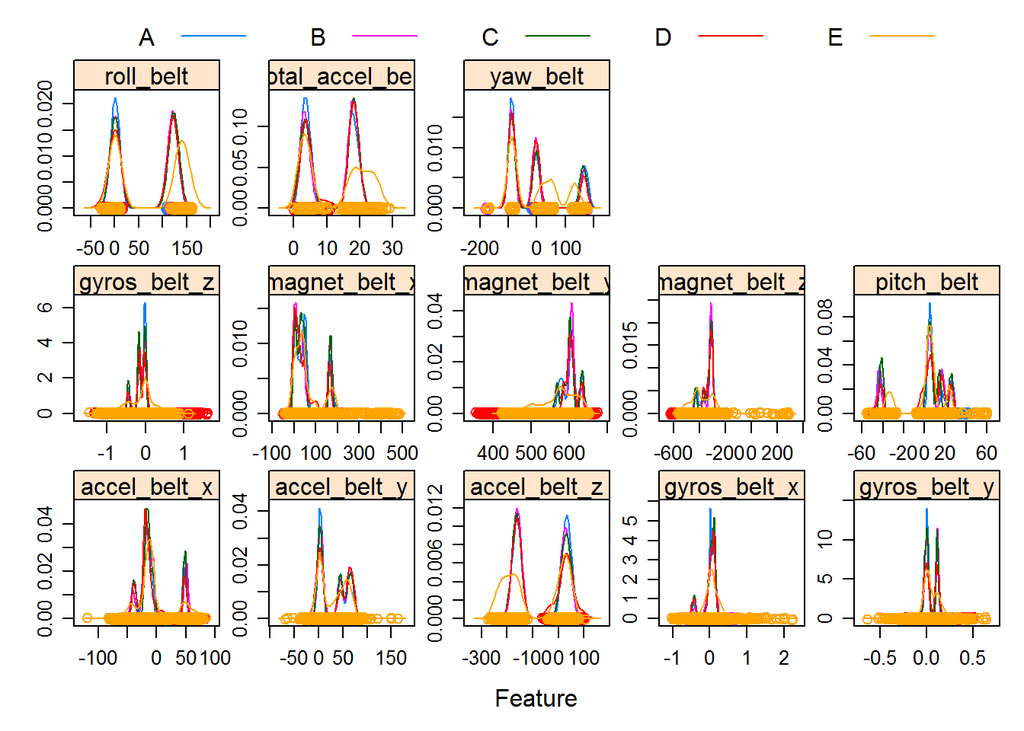

```r
featurePlot(x=train[, grep("_belt", names(train))], y=train$classe, plot="density", scales=list(x=list(relation="free"), y=list(relation="free")), auto.key=list(columns=5))
```

```r
set.seed(336338)
inTrain <- createDataPartition(y=train$classe, p=0.7, list=FALSE)
train <- train[inTrain, ]
test <- train[-inTrain, ]
```

Now the train dataset and test dataset are ready to build a predictive model.

## Prediction Model

In this report we are going to experiment with boosting and random forests and see which of those two would give us the best accuracy.

### Cross Validation

```r
tr_control <- trainControl(method='cv', number = 5)
```

### Generalized Boosting Regression Model

We will start with boosting. This is going to try and fit a lot of weak predictors and then weight them and combine them. By doing this we should end up with a much stronger predictor. Notice that the trControl parameter is set using the variable we created earlier telling train() to do cross validation while training.

```r
model_gbm <- train(classe ~ .,  data=train, trControl=tr_control,  method='gbm', verbose=F)
```

```r
predict_gbm <- predict(model_gbm, newdata=test)
cm_gbm <- confusionMatrix(predict_gbm, test$classe)
print(cm_gbm)
```

```
## Confusion Matrix and Statistics
##
##           Reference
## Prediction    A    B    C    D    E
##          A 1172   28    0    0    0
##          B    7  740   16    1    3
##          C    3   11  710   25    4
##          D    3    0    7  654    9
##          E    0    0    1    3  694
##
## Overall Statistics
##
##                Accuracy : 0.9704
##                  95% CI : (0.9648, 0.9754)
##     No Information Rate : 0.2897
##     P-Value [Acc > NIR] : < 2.2e-16
##
##                   Kappa : 0.9625
##  Mcnemar's Test P-Value : NA
##
## Statistics by Class:
##
##                      Class: A Class: B Class: C Class: D Class: E
## Sensitivity            0.9890   0.9499   0.9673   0.9575   0.9775
## Specificity            0.9904   0.9918   0.9872   0.9944   0.9988
## Pos Pred Value         0.9767   0.9648   0.9429   0.9718   0.9943
## Neg Pred Value         0.9955   0.9883   0.9928   0.9915   0.9953
## Prevalence             0.2897   0.1904   0.1794   0.1670   0.1736
## Detection Rate         0.2865   0.1809   0.1736   0.1599   0.1696
## Detection Prevalence   0.2933   0.1875   0.1841   0.1645   0.1706
## Balanced Accuracy      0.9897   0.9709   0.9772   0.9760   0.9881
```

### Random Forests

Next let’s compare the random forest method. Again we are going to use the same train control to do cross validation.

```r
model_rf <- train(classe ~ .,  data=train, trControl=tr_control,  method='rf', verbose=F)
```

Now we use the random forests model to predict on the same testing set we used to evaluate the boosting method.

```r
predict_rf <- predict(model_rf, newdata=test)
cm_rf <- confusionMatrix(predict_rf, test$classe)
print(cm_rf)
```

```
## Confusion Matrix and Statistics
##
##           Reference
## Prediction    A    B    C    D    E
##          A 1185    0    0    0    0
##          B    0  779    0    0    0
##          C    0    0  734    0    0
##          D    0    0    0  683    0
##          E    0    0    0    0  710
##
## Overall Statistics
##
##                Accuracy : 1
##                  95% CI : (0.9991, 1)
##     No Information Rate : 0.2897
##     P-Value [Acc > NIR] : < 2.2e-16
##
##                   Kappa : 1
##  Mcnemar's Test P-Value : NA
##
## Statistics by Class:
##
##                      Class: A Class: B Class: C Class: D Class: E
## Sensitivity            1.0000   1.0000   1.0000    1.000   1.0000
## Specificity            1.0000   1.0000   1.0000    1.000   1.0000
## Pos Pred Value         1.0000   1.0000   1.0000    1.000   1.0000
## Neg Pred Value         1.0000   1.0000   1.0000    1.000   1.0000
## Prevalence             0.2897   0.1904   0.1794    0.167   0.1736
## Detection Rate         0.2897   0.1904   0.1794    0.167   0.1736
## Detection Prevalence   0.2897   0.1904   0.1794    0.167   0.1736
## Balanced Accuracy      1.0000   1.0000   1.0000    1.000   1.0000
```

## Prediction

```r
predict_valid <- predict(model_rf, newdata=valid)
predict_valid_df <- data.frame(problem_id=valid$problem_id, predicted=predict_valid)
print(predict_valid_df)
```

```
##    problem_id predicted
## 1           1         B
## 2           2         A
## 3           3         B
## 4           4         A
## 5           5         A
## 6           6         E
## 7           7         D
## 8           8         B
## 9           9         A
## 10         10         A
## 11         11         B
## 12         12         C
## 13         13         B
## 14         14         A
## 15         15         E
## 16         16         E
## 17         17         A
## 18         18         B
## 19         19         B
## 20         20         B
```